## Data Load

```python
import pandas as pd

df_eCommerce_Info = pd.read_csv('https://storage.googleapis.com/datalynn-datasets/interview-challenge/technology/Oracle_Database_Management_System/df_eCommerce_Info.csv')
df_Requests = pd.read_csv('https://storage.googleapis.com/datalynn-datasets/interview-challenge/technology/Oracle_Database_Management_System/df_Requests.csv')
```

# Solution

## Question 1

**Scenario:** The eCommerce platforms vary in their user bases, potentially leading to varying levels of requests to Oracle's Database. By understanding the request patterns, Oracle can better manage resources.

- Extract features from the `Requests` and `eCommerce_Info` tables to determine the relationship between the user base of an eCommerce platform and the average duration of its requests. Do larger platforms generate longer request times?

**Hints**

1. **Merge the Tables:** We will first merge the `Requests` table and the `eCommerce_Info` table on the `Website` column. This will allow us to correlate the user base of an eCommerce platform with its request durations.
2. **Group and Average:** Next, we'll group by the `Website` and calculate the average duration of its requests.
3. **Correlation Analysis:** We will then determine the correlation between the `User_Base` and the average `Duration`. A positive correlation would indicate that as the user base increases, the request duration also increases, and vice-versa.
4. **Plotting:** For better visualization, we'll plot a scatter plot of `User_Base` vs. average `Duration`.

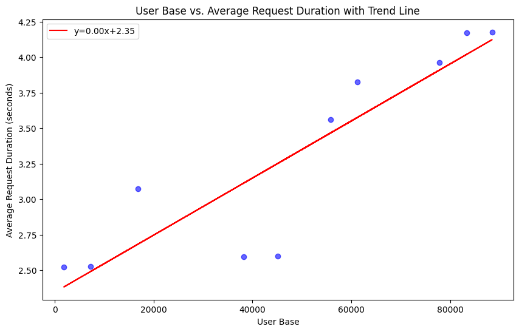

```python
import numpy as np
import matplotlib.pyplot as plt
from scipy.stats import linregress

# Step 1: Merge the tables
merged_df = df_Requests.merge(df_eCommerce_Info, on='Website')

# Step 2: Group by 'Website' and calculate the average duration
average_durations = merged_df.groupby('Website')['Duration'].mean().reset_index()

# Merge the average durations with df_eCommerce_Info to get user bases
final_df = df_eCommerce_Info.merge(average_durations, on='Website')

# Step 3: Correlation Analysis
correlation = final_df['User_Base'].corr(final_df['Duration'])


# Step 4: Plotting with Trend Line

# Get the regression line parameters
slope, intercept, r_value, p_value, std_err = linregress(final_df['User_Base'], final_df['Duration'])

# Generate the y-values based on the regression line
line = slope*final_df['User_Base'] + intercept

plt.figure(figsize=(10, 6))
plt.scatter(final_df['User_Base'], final_df['Duration'], color='blue', alpha=0.6)
plt.plot(final_df['User_Base'], line, color='red', label=f'y={slope:.2f}x+{intercept:.2f}')

plt.title('User Base vs. Average Request Duration with Trend Line')
plt.xlabel('User Base')
plt.ylabel('Average Request Duration (seconds)')
plt.legend()
plt.show()
```

## Question 2

**Scenario:** During peak hours, databases are more likely to be strained. We need to understand if certain websites intensify this strain.

- Analyze the data to identify if there's a correlation between the peak hours of the highest user-base platforms and increased request durations. Is Oracle's database slower during these peak times?

**Hints**

1. **Identify Highest User-Base Platforms:** Identify the eCommerce platforms with the highest user bases.
2. **Filtering Requests by Peak Hours:** Based on the provided peak hours, filter the `Requests` table for requests made during these hours.
3. **Calculate Average Duration During Peak Hours:** Calculate the average request duration during these peak hours for the high user-base platforms.
4. **Calculate Average Duration Outside Peak Hours:** Calculate the average request duration outside these peak hours.

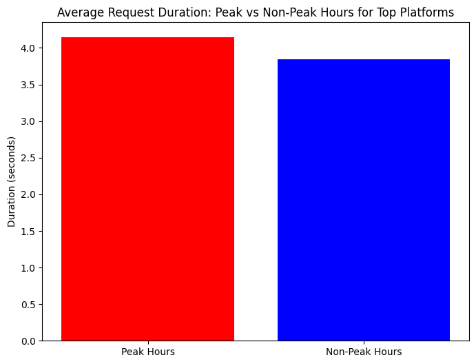

```python
import pandas as pd

# Step 1: Identify Highest User-Base Platforms
top_websites = df_eCommerce_Info.nlargest(5, 'User_Base')['Website'].tolist() # Considering top 5 platforms

# Step 2: Filter Requests by Peak Hours
peak_hours_ranges = [(6, 8), (12, 14), (14, 16)]
peak_dataframes = []

df_Requests['Time_Stamp'] = pd.to_datetime(df_Requests['Time_Stamp'])

for start_hour, end_hour in peak_hours_ranges:
    peak_df = df_Requests[(df_Requests['Website'].isin(top_websites)) & (df_Requests['Time_Stamp'].dt.hour >= start_hour) & (df_Requests['Time_Stamp'].dt.hour <= end_hour)]
    peak_dataframes.append(peak_df)

peak_df_combined = pd.concat(peak_dataframes)

# Step 3: Calculate Average Duration During Peak Hours
avg_duration_peak = peak_df_combined['Duration'].mean()

# Step 4: Calculate Average Duration Outside Peak Hours
avg_duration_non_peak = df_Requests[(~df_Requests.index.isin(peak_df_combined.index)) & (df_Requests['Website'].isin(top_websites))]['Duration'].mean()

# Step 5: Plotting
import matplotlib.pyplot as plt

labels = ['Peak Hours', 'Non-Peak Hours']
values = [avg_duration_peak, avg_duration_non_peak]

plt.figure(figsize=(8, 6))
plt.bar(labels, values, color=['red', 'blue'])
plt.title('Average Request Duration: Peak vs Non-Peak Hours for Top Platforms')
plt.ylabel('Duration (seconds)')
plt.show()
```

## Question 3

**Scenario:** Oracle is curious about the distribution of query types among different platforms.

- Using statistical methods, analyze the `Query_Type` distribution among the top 5 eCommerce platforms by user base. Are certain query types predominant among larger platforms? (please use SQL to answer this question)

**Hints**

1. **Data Retrieval:** First, we'll determine the top 5 eCommerce platforms based on their user base.
2. **Analysis:** We will then analyze the distribution of the `Query_Type` for each of these platforms.
3. **Visualization/Statistics:** To understand the distribution better, we can also visualize it or use statistics to get a sense of predominance.

```python
import sqlite3

# Create a new SQLite database in memory
conn = sqlite3.connect(':memory:')
c = conn.cursor()

# Convert dataframes to SQLite tables
df_eCommerce_Info.to_sql('eCommerce_Info', conn, if_exists='replace')
df_Requests.to_sql('Requests', conn, if_exists='replace')
# Determine the top 5 eCommerce platforms by user base
c.execute('''
    SELECT Website
    FROM eCommerce_Info
    ORDER BY User_Base DESC
    LIMIT 5
''')
top_5_platforms = [row[0] for row in c.fetchall()]

# Retrieve the Query_Type distribution for each of these platforms
c.execute('''
    WITH Top5Platforms AS (
        SELECT Website
        FROM eCommerce_Info
        ORDER BY User_Base DESC
        LIMIT 5
    )
    SELECT r.Website, r.Query_Type, COUNT(*) as Query_Count
    FROM Requests r
    JOIN Top5Platforms t ON r.Website = t.Website
    GROUP BY r.Website, r.Query_Type
    ORDER BY r.Website, Query_Count DESC
''')
query_distribution = c.fetchall()

for row in query_distribution:
    print(row)
```

```
('Website_10', 'INSERT', 34)
('Website_10', 'UPDATE', 29)
('Website_10', 'SELECT', 21)
('Website_10', 'DELETE', 20)
('Website_3', 'UPDATE', 26)
('Website_3', 'DELETE', 23)
('Website_3', 'INSERT', 22)
('Website_3', 'SELECT', 21)
('Website_4', 'SELECT', 26)
('Website_4', 'INSERT', 23)
('Website_4', 'DELETE', 22)
('Website_4', 'UPDATE', 21)
('Website_6', 'INSERT', 29)
('Website_6', 'SELECT', 25)
('Website_6', 'UPDATE', 23)
('Website_6', 'DELETE', 21)
('Website_8', 'SELECT', 32)
('Website_8', 'UPDATE', 28)
('Website_8', 'INSERT', 23)
('Website_8', 'DELETE', 23)
```

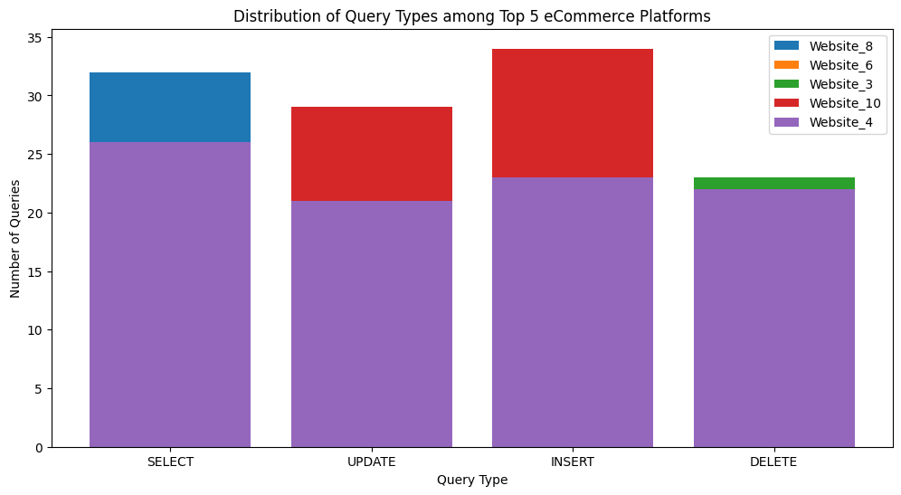

```python
import matplotlib.pyplot as plt
import pandas as pd

# Convert results to a DataFrame for easy plotting
df_query_dist = pd.DataFrame(query_distribution, columns=['Website', 'Query_Type', 'Query_Count'])

# Plotting
plt.figure(figsize=(12, 6))
for platform in top_5_platforms:
    subset = df_query_dist[df_query_dist['Website'] == platform]
    plt.bar(subset['Query_Type'], subset['Query_Count'], label=platform)

plt.title("Distribution of Query Types among Top 5 eCommerce Platforms")
plt.xlabel("Query Type")
plt.ylabel("Number of Queries")
plt.legend()
plt.show()
```

## Question 4

**Scenario:** Improving the response rate is crucial for enhancing user experience. We suspect that certain types of queries might be more prone to failures.

**Hints**

1. **Data Preprocessing:**
   - Handle missing values (if any).
   - Convert categorical features into numerical representations using encoding techniques (like One-Hot Encoding).
   - Split the data into training and testing sets.
2. **Model Building:**
   - For simplicity, we'll use a RandomForest Classifier, which also allows us to determine feature importance.
   - Train the model on the training set and evaluate its performance on the test set.
3. **Identifying Influential Features:**
   - Extract the feature importance from the RandomForest model.
   - Visualize the feature importance using a bar plot.

```python
# Check data types first
print(df_Requests.dtypes)

# Convert 'Time_Stamp' to a numerical format
df_Requests['Time_Stamp'] = pd.to_datetime(df_Requests['Time_Stamp'])
df_Requests['Hour'] = df_Requests['Time_Stamp'].dt.hour
df_Requests['Minute'] = df_Requests['Time_Stamp'].dt.minute
df_Requests['Second'] = df_Requests['Time_Stamp'].dt.second
```

```
Request_ID             int64
Time_Stamp    datetime64[ns]
Website               object
Query_Type            object
Duration             float64
Response              object
dtype: object
```

```python
import pandas as pd
from sklearn.model_selection import train_test_split
from sklearn.ensemble import RandomForestClassifier
from sklearn.metrics import accuracy_score, classification_report
import matplotlib.pyplot as plt
import warnings; warnings.simplefilter('ignore')

# Drop the original 'Time_Stamp' column
df_Requests = df_Requests.drop('Time_Stamp', axis=1)

# Now, let's try the encoding and model training steps again

# One-Hot Encoding for Categorical Features
df_encoded = pd.get_dummies(df_Requests, columns=['Website', 'Query_Type'], drop_first=True)

# Splitting the data
X = df_encoded.drop('Response', axis=1)
y = df_encoded['Response']

X_train, X_test, y_train, y_test = train_test_split(X, y, test_size=0.2, random_state=42)

# Model Building
clf = RandomForestClassifier(random_state=42)
clf.fit(X_train, y_train)
y_pred = clf.predict(X_test)

print("Accuracy:", accuracy_score(y_test, y_pred))
print(classification_report(y_test, y_pred))
```

```
Accuracy: 0.91
              precision    recall  f1-score   support

      Failed       0.00      0.00      0.00        18
  Successful       0.91      1.00      0.95       182

    accuracy                           0.91       200
   macro avg       0.46      0.50      0.48       200
weighted avg       0.83      0.91      0.87       200
```

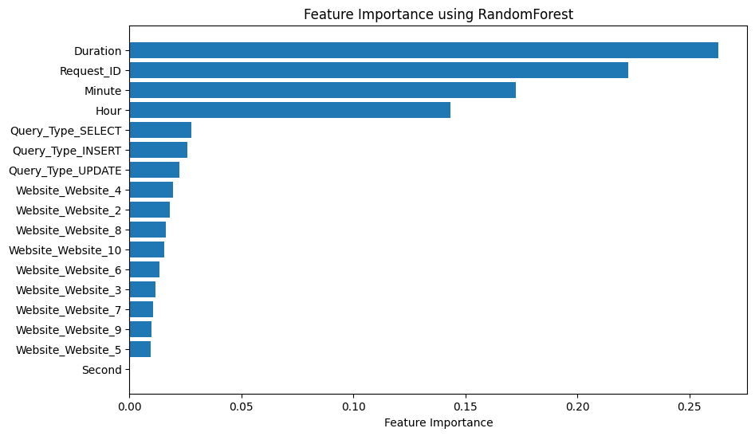

```python
# Step 3: Identifying Influential Features

feature_importances = clf.feature_importances_
features = X.columns

# Visualization
plt.figure(figsize=(10, 6))
sorted_idx = feature_importances.argsort()
plt.barh(features[sorted_idx], feature_importances[sorted_idx])
plt.xlabel('Feature Importance')
plt.title('Feature Importance using RandomForest')
plt.show()
```